# HW 4

Brandon Keck

2024-10-14

### 2.6-1 An excellent free-throw shooter attempts several free throws until she misses.

#### (a) If p = 0.9 is her probability of making a free throw, what is the probability of having the first miss on the 13th attempt or later?

P(X>=13) = 1 - P(X=<12) We are given that p = 0.9. (1-p) = (1-0.9)=0.1

Let X be the random variable representing the number of attempts until the first miss occurs.

```r
1 - pgeom(11, 0.1)
```

```
## [1] 0.2824295
```

$\boxed{0.2824295}$

#### (b) If she continues shooting until she misses three, what is the probability that the third miss occurs on the 30th attempt?

P(X=30)

```r
choose(30 - 1, 3 - 1) * (0.1^3) * (0.9^(30 - 3))
```

```
## [1] 0.02360879
```

$\boxed{0.02360879}$

### 3.1-1 Show that the mean, variance, and mgf of the uniform distribution are as given in this section.

The mean $(\mu)$ of a uniform distribution $(X\sim U(a,b))$ is

$f(x) = \frac{1}{b-a}$, for $a\le {x} \le b$

$E(X) = \int_a^b x*f(x) dx$

$= \int_a^b x* \frac{1}{b-a}dx$

$= \frac{1}{b-a} * \int_a^b xdx$

$= \frac{1}{b-a} * \frac{x^2}{2}]_a^b$

$= \frac{1}{b-a} * [\frac{b^2}{2}-\frac{a^2}{2}]$

$= \frac{b+a}{2}$

Therefore, $\boxed{E(X)=\frac{b+a}{2}}$

In order to find the variance we must first calculate $E(X^2)$

$E(X^2) = \int_a^b x^2*f(x) dx$

$= \int_a^b x^2* \frac{1}{b-a}dx$

$= \frac{1}{b-a} * \int_a^b x^2dx$

$= \frac{1}{b-a} * \frac{x^3}{3}]_a^b$

$= \frac{1}{b-a} * [\frac{b^3}{3}-\frac{a^3}{3}]$

We can use the fact that $b^3-a^3 = (b-a)(b^2+ab+a^2)$

$= \frac{1}{b-a} * [\frac{(b-a) (b^2+ab+a^2)}{3}]$

$=\boxed{ \frac{(b^2+ab+a^2)}{3}}$

The formula to solve for the $Var(X) = E(X^2) - [E(X)]^2$

$Var(X)= \frac{b^2+ab+a^2}{3} - (\frac{b+a}{2})^2$

$= \frac{b^2+ab+a^2}{3} - \frac{b^2+2ab+a^2}{4}$

$= \frac{(4b^2+4ab+4a^2)}{12} - \frac{3b^2+6ab+3a^2}{12}$

$= \frac{b^2-2ab+a^2}{12}$

Therefore the $Var(X) = \boxed{\frac{b^2-2ab+a^2}{12}}$

The Moment Generating function is $M(t) = \int^{\infty}_{-\infty} e^{tx}*f(x)dx, -h < t < h$

$\int_a^b e^{tx}* \frac{1}{b-a}dx$

$= \frac{1}{b-a}*\int_a^b e^{tx}dx$

$= \frac{1}{b-a}*\frac{e^{tx}}{t}]_a^b$

$= \frac{1}{b-a}* [\frac{e^{bt}}{t}-\frac{e^{at}}{t}]$

$= \frac{1}{b-a}* [\frac{e^{bt} - e^{at}}{t}]$

$= [\frac{e^{bt}-e^{at}}{t(b-a)}], t \neq 0$

$M_X(t) = \begin{cases} \frac{e^{tb} - e^{ta}}{t(b - a)} & \text{if } t \neq 0, \\ 1 & \text{if } t = 0. \end{cases}$

### 3.1-3 Customers arrive randomly at a bank teller’s window. Given that one customer arrived during a particular ten-minute period, let X equal the time within the ten minutes that the customer arrived. If X is U(0, 10), find

#### (a) The pdf of X.

X ~ U$(a,b), a\le x \le b$

$f(x)=\frac{1}{b-a}, a\le x \le b$

a = 0 b = 10

The PDF for X is constant over the interval [0,10] so,

$\boxed{f(x)=\frac{1}{10-0} = \frac{1}{10}, for\ 0 \le x \le10}$

#### (b) P(X ≥ 8).

$P(X\le8) = \int_0^8 \frac{1}{10}dx$

$= \frac{1}{10}x]_0^8$

$= \frac{8-0}{10}$

$= \frac{8}{10}$

using the complement to obtain the probability

```r
1-0.8
```

```
## [1] 0.2
```

$\boxed{0.2}$

#### (c) P(2 ≤ X < 8).

$P(2 ≤ X < 8) = \int_2^8 \frac{1}{10}dx$

$= \frac{1}{10}x]_2^8$

$= \frac{8-2}{10}$

$=\boxed{ \frac{6}{10}}$

### (d) E(X).

$E(X) = \int_{0}^{10}x * \frac{1}{10}dx$

$= \frac{1}{10}* \int_{0}^{10}xdx$

$= \frac{1}{10}*\frac{x^2}{2}]_0^{10}$

$= \frac{1}{10}*\frac{10^2-0^2}{2}$

$= \frac{10}{2}$

$=\boxed{5}$

### (e) Var(X).

$E(X^2) = \int_{0}^{10}x^2 * \frac{1}{10}dx$

$= \frac{1}{10}* \int_{0}^{10}x^2dx$

$= \frac{1}{10}*\frac{x^3}{3}]_0^{10}$

$= \frac{1}{10}*\frac{10^3-0^3}{3}$

$= \frac{100}{3}$

$Var(X) = E(X^2)-[E(X)]^2$

$\frac{100}{3}-{5^2}$

$\boxed{\frac{25}{3}}$

### 3.1-5 Let Y have a uniform distribution U(0, 1), and let W = a + (b − a)Y, a < b. (a) Find the cdf of W. HINT: Find P[a + (b − a)Y ≤ w].

$Given \ that \ W = a+(b-a)Y, we \ need \ to \ solve \ for \ Y$

$P(W \le w) = P(a+(b-a)Y \le w)$

$= (b-a)Y \le w-a$

$= Y \le \frac{w-a}{b-a}$

$\int_0^{\frac{w-a}{b-a}}dy$

$y]_0^{\frac{w-a}{b-a}}$

$\frac{w-a}{b-a}$

$Therefore, \ the \ cdf \ of \ W \ is \ \boxed{F(w) = \frac{w-a}{b-a}, for \ a \le w \le b}$

#### (b) How is W distributed?

If we consider X is a continuous random variable that follows the uniform distribution then the probability density function of X would be:

$f(x) = \frac{1}{b-a}, for \ a \le x \le b$

The distribution function of X will then be:

$P(X \le x) = \frac{x-a}{b-a}$

Comparing that to the distribution function of W, $P(W \le w) = \frac{w-a}{b-a}$

Therefore, W is distributed uniformly.

### 3.1-8 For each of the following functions, (i) find the constant c so that f(x) is a pdf of a random variable X; (ii) find the cdf, F(x) = P(X ≤ x); (iv) find μ, σ2,

#### (a) f(x) = x3/4, 0 < x < c.

##### Part (i)

$f(x)= \frac{x^3}{4}, where 0 < x < c$

$\int_0^cf(x)dx=1$

$\int_0^c \frac{x^3}{4}dx=1$

$\frac{1}{4}*\int_0^cx^3dx=1$

$\frac{1}{4}*\frac{x^4}{4}]_0^c=1$

$\frac{x^4}{16}]_0^c=1$

$\frac{c^4}{4}-\frac{0^4}{4}=1$

$\frac{c^4}{16}=1$

$c^4=1$

$c=\sqrt[4]{16}$

$c=\boxed{2}$

##### Part (ii)

$P(X\le x) = \int p(x)dx$

$F(X)= \int_0^x \frac{t^3}{4}dt$

$= \frac{1}{4} * \int_0^x t^3dt$

$= \frac{1}{4} * \frac{t^4}{4}]_0^x$

$= \frac{t^4}{16}]_0^x$

$= \frac{x^4}{16}- \frac{0^4}{16}$

$=\boxed{ \frac{x^4}{16}, 0 \le x \le 2}$

#### Part (iv)

$\mu=E(X) = \int_0^c x*f(x)dx$

$= \int_0^2x* \frac{x^3}{4}dx$

$= \frac{1}{4}* \int_0^2 x^4dx$

$= \frac{1}{4}*[\frac{x^5}{5}]_0^2]$

$= \frac{2^5}{5} - \frac{0^5}{5}$

$= \boxed{ \frac{32}{20}}$

$\sigma^2=E(X) = \int_0^cx^2*f(x)dx$

$= \int_0^2x^2* \frac{x^3}{4}dx$

$= \frac{1}{4}* \int_0^2x^5dx$

$= \frac{1}{4} * [\frac{x^6}{6}]_0^2]$

$= \frac{x^6}{24}]_0^2$

$= \frac{2^6}{24} - \frac{0^6}{24}$

$= \frac{64}{24}$

Computing the variance formula $E(X^2-[E(X)]^2$

$= \frac{64}{24}- \frac{32}{20}$

```r
(64/24) - (32/20)^2
```

```
## [1] 0.1066667
```

So $Var(X) = \boxed{0.1066667}$

#### (b) f(x) = (3/16)x2, −c < x < c.

##### Part(i)

$f(x) = \frac{3}{16}*x^2,\ -c < x < c$

$= \int_{-c}^c \frac{3}{16}*x^2dx=1$

$= \frac{3}{16}* \int_{-c}^cx^2dx=1$

$= \frac{3}{16}* [\frac{x^3}{3}]]_{-c}^c=1$

$= \frac{3x^3}{48}]_{-c}^c=1$

$= \frac{3c^3}{48}- [\frac{-3c^3}{48}]=1$

$= \frac{6c^3}{48}=1$

$= 6c^3=48$

$=c^3=48$

$=c= \boxed{2}$

##### Part (ii)

$P(X \le x) = \int p(x)dx$

$F(x) = \int_{-2}^x \frac{3}{16}x^2dt$

$= \frac{3}{16}* \int_{-2}^xt^2dt$

$= \frac{3}{16}* [\frac{t^3}{3}]_{-2}^x$

$= \frac{t^3}{16}]_{-2}^x$

$= \frac{x^3}{16}- [\frac{-2^3}{16}]$

$=\boxed{ \frac{x^3+8}{16}}$

##### Part (iv)

$\mu = E(X) = \int_{-2}^2 x *\frac{3}{16}*x^2dx$

$= \int_{-2}^2 x* \frac{3}{16}x^2dx$

$= \frac{3}{16}* \int_{-2}^2x^3dx$

$= \frac{3}{16} * \frac{x^4}{4}]_{-2}^2$

$= \frac{3x^4}{15}]_{-2}^2$

$\frac{3(2)^4}{4} - \frac{3(-2)}{4}$

$= \frac{48}{64} - \frac{48}{64}$

$Therefore,\ \boxed{\mu = 0}$

$\sigma^2 = E(X) - [E(X)]^2$

$Since\ E(X) = 0\ the\ variance\ simplifies\ to \ \sigma = E(X^2)$

$= \int_{-2}^2x^2 * \frac{3}{16}x^2dx$

$= \frac{3}{16} * \int_{-2}^2x^4dx$

$= \frac{3}{16} * \frac{x^5}{5}]_{-2}^2$

$= \frac{3(2)^5}{80}- \frac{3(-2)^5}{80}$

$= \frac{192}{80}$

```r
192/80
```

```
## [1] 2.4
```

$Therefore,\sigma^2 = \boxed{2.4}$

#### (c) f(x) = c/ √x, 0 < x < 1.

##### Part (i)

$\int_0^1 f(x)dx=1$

$\int_0^1 \frac{c}{\sqrt{x}}dx=1$

$$\int \frac{c}{\sqrt{x}}=2
\sqrt{x}$$

$$\int_0^1 \frac{c}{\sqrt{x}} = c * [2\sqrt{x}]_0^1$$

$$= c * (2-0) = 2c$$

$$2c = 1 -> c = \frac{1}{2}$$

$$So \ the \ pdf \ is: \boxed{f(x) = \frac{1}{2*\sqrt{x}}, 0 < x <
1}$$

##### Part (ii)

$$F(x) = \int_0^x \frac{1}{2*\sqrt{t}} dt$$

$$F(x) = [\sqrt{t}]_0^x = \sqrt{x}$$

$F(x) = \begin{cases} 0 & \text{if } x \leq 0, \\ \sqrt{x} & \text{if } 0 < x < 1, \\ 1 & \text{if } x \geq 1. \end{cases}$

##### Part (iv)

$\mu = E(X) = \int_0^1 x*f(x)dx = \int_0^1x* \frac{1}{2*\sqrt{x}}dx$

$$= \frac{1}{2} = \int_0^1 \sqrt{x}dx$$

$$\mu = \frac{1}{2} * [\frac{2}{3}x^{\frac{3}{2}}]_0^1$$

$$= \frac{1}{2} * \frac{2}{3} = \frac{1}{3}$$

$$\boxed{\mu = \frac{1}{3}}$$

$$\sigma^2 = E(x - \mu)^2$$

$$=\int_0^1 x^2f(x)dx = \int_0^1 x^2 * \frac{1}{2\sqrt{x}}dx$$

$$= \frac{1}{2} \int_0^1 x^{\frac{3}{2}}dx$$
$$E(x^2) = \frac{1}{2}* [\frac{2}{5}x^{\frac{5}{2}}]_0^1 = \frac{1}{2} *
\frac{2}{5}$$

$$= \frac{1}{5}$$

$$\sigma^2 = E(x- \mu)^2 = \frac{1}{5}- (\frac{1}{3})^2 = \frac{1}{5}-
\frac{1}{9}$$

$$\boxed{\sigma^2 = \frac{4}{45}}$$

The PDF is unbounded near x = 0

### 3.1-9 Let the random variable X have the pdf f(x) = 2(1 − x), 0 ≤ x ≤ 1, zero elsewhere.

#### (b) Determine and sketch the graph of the cdf of X.

$For\ x <0:$ $F(X) = 0 for\ x < 0$

$For\ 0 \le x \le 1:$ $F(x) = \int_0^x 2(1-t)dt$

$F(x) = 2 \int_0^x(1-t)dt$

$2 [t-\frac{t^2}{2}]_0^x$

$2(x- \frac{x^2}{2})$

$Thus, \ for \ 0 \le x \le 1: F(x) = 2x-x^2$

$For \ x > 1 \ the \ cdf \ becomes \ 1$

$F(x) = \begin{cases} \ 0 & \text{if } x < 0, \\ \ 2x-x^2 & \text{if } 0 \le x \le 1 \\ 1 & \text{if } x > 0. \end{cases}$

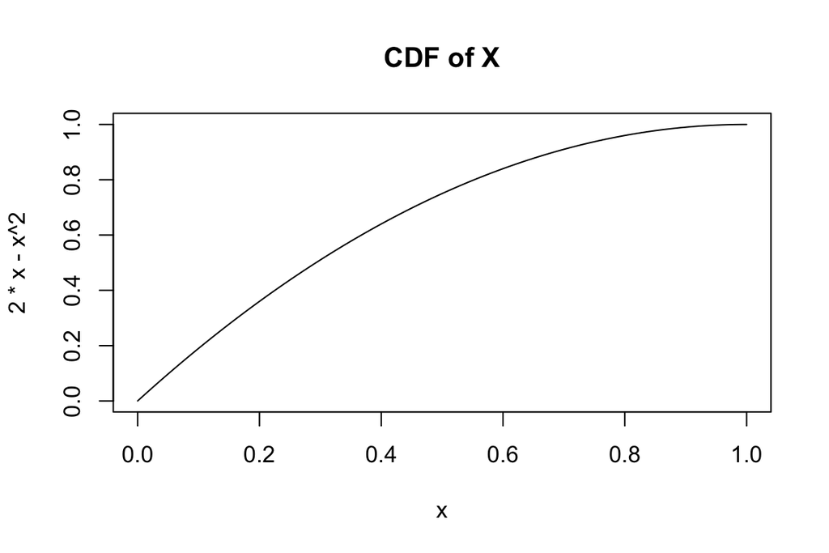

```r
curve(2*x - x^2, from = 0, to = 1, main = "CDF of X")
```

#### (c)

##### Part (i)

P(0 ≤ X ≤ 1/2)

```r
# Define the PDF function
func1 <- function(x) {
  2 * (1 - x)
}

# Use integrate to calculate P(0 ≤ X ≤ 1/2)
result <- integrate(func1, lower = 0, upper = 1/2)

result
```

```
## 0.75 with absolute error < 8.3e-15
```

$$P(0 \le X \le \frac{1}{2}) = \boxed{0.75}$$

##### Part (ii)

P(1/4 ≤ X ≤ 3/4),

```r
# Define the PDF function
func2 <- function(x) {
  2 * (1 - x)
}

# Use integrate to calculate P(1/4 ≤ X ≤ 3/4)
result <- integrate(func1, lower = 1/4, upper = 3/4)

result
```

```
## 0.5 with absolute error < 5.6e-15
```

$$P(\frac{1}{4} \le X \le \frac{3}{4}) = \boxed{0.5}$$

##### Part(iii)

P(X = 3/4),

For a continuous random variable, the probability that X takes on a specific value is 0

$$P(X= \frac{3}{4}) = \boxed{0}$$

##### Part (iv)

```r
# Define the PDF function
func2 <- function(x) {
  2 * (1 - x)
}

# Use integrate to calculate P(3/4 ≤ X ≤ 1)
result <- integrate(func1, lower = 3/4, upper = 1)

result
```

```
## 0.0625 with absolute error < 6.9e-16
```

$$P(X+ \frac{3}{4})= \boxed{0.0625}$$

### 3.2-2 Telephone calls arrive at a doctor’s office according to a Poisson process on the average of two every three minutes. Let X denote the waiting time until the first call that arrives after 10 A.M.

#### (a) What is the pdf of X?

On average there are 2 calls every 3 minutes.

$\lambda = \frac{2}{3}$

The pdf of an expenential distribution is

$f(x) = \frac{1}{\theta}e^{\frac{-x}{\theta}}$

$f(x) = \frac{1}{\frac{3}{2}}e^{\frac{-x}{\frac{3}{2}}}$

$\frac{2}{3}e^{\frac{-2x}{3}}$

$The \ pdf \ is \ \boxed{f(x) = \frac{2}{3}e^{\frac{-2x}{3}}, 0 \le x < \infty}$

#### (b) Find P(X > 2).

The CDF of an exponential distribution is given by:

$F_x(x)= 1 - e^{\frac{-x}{\theta}}, \ 0 \le x < \infty$

$P(X>2) = 1 - P(X \le 2)$

$P(X>2) = 1 - (1-e^{\frac{-2}{\frac{3}{2}}})$

$P(X>2) = e^{\frac{-4}{3}}$

```r
exp(-4/3)
```

```
## [1] 0.2635971
```

$Therefore, \ P(X>2) = \boxed{0.2635971}$

### 3.2-5 There are times when a shifted exponential model is appropriate. That is, let the pdf of X be f(x) = 1 / θ e−(x−δ)/θ, δ< x < ∞. (a) Define the cdf of X.

$F(x) = \int_{\delta}^x f(x)dx$

$F(x) = \int_{\delta}^x \frac{1}{\theta}*e^ \frac{-(x- \delta)}{\theta}dx$

$= \int_{\delta}^x \frac{1}{\theta}*e^ \frac{\frac{-x}{\theta+\delta}}{\theta}dx$

$=\frac{1}{\theta}*e^ \frac{\delta}{\theta} \int_\theta^x e^{\frac{-x}{\theta}}$

$=\frac{1}{\theta}e^{\frac{\delta}{\theta}}((\frac{1}{\frac{-1}{\theta}})e^{\frac{-x}{\theta}})_\delta^x$

$=\frac{1}{\theta}e^{\frac{\delta}{\theta}}(-\theta e^{\frac{-x}{\theta}})_\delta^x$

$=-e^{\frac{\delta}{\theta}}(e^{\frac{-x}{\theta}})_\delta^x$

$=-e^{\frac{\delta}{\theta}}(e^{\frac{-x}{\theta}}-e^{\frac{-\delta}{\theta}})$

$= -e^{\frac{-x}{\theta}+\frac{\delta}{\theta}}+e^{\frac{-\delta}{\theta}+\delta \theta}$

$= -e^{\frac{-x-\delta}{\delta}}+e^0$

$=1-e^{-\frac{x-\delta}{\theta}}$

$\boxed{F(x) =1 -e^{-\frac{x-\delta}{\theta}}, \delta \le x \le \infty}$

##### Part (b)

$$\mu = E(X) = \int_\delta^\infty x
f(x)dx$$

$$\mu = \int_\delta^\infty x*
\frac{1}{\theta}e^{\frac{-(x-\delta)}{\theta}}dx$$

$$\mu = \int_0^ \infty (\theta u + \delta)e^{-u}du$$

$$\mu = \int_0^ \infty \theta u e^{-u} du + \int_0^\infty \delta e ^{-u}du$$

$$\int_0^\infty \delta e^{-u}du = \delta * [-e^{-u}] = \delta$$
$$\int_0^\infty ue^{-u}du=1$$
$$\mu = \theta * 1 + \delta = \theta+\delta$$
$$\boxed{\mu = \theta + \delta}$$

$$\sigma^2 = E(x- \mu)^2$$

$$= \int_\delta^\infty (\theta u +\delta)^2e^{-u}du$$
$$(\theta u + \delta)^2 = \theta^2 u^2 + 2 \theta u \delta + \delta^2$$

$$= \int_0^\infty \theta^2 u^2e^{-u}du + \int_0^\infty 2 \theta u \delta
e^{-u}du + \int_0^\infty \delta^2 e^{-u}du$$

$$\int_0^\infty \theta^2 u^2 e^{-u}du = 2 \theta^2$$

$$\int_0^\infty 2 \theta \delta e^{-u}du = 2 \theta \delta$$

$$\int_0^\infty \delta^2 e^{-u}du = \delta^2$$
$$E(X)^2 = 2 \theta^2 + 2 \theta \delta + \delta^2$$

$$\sigma^2 = E(X)^2 - \mu^2 = (2 \theta^2+2 \theta + \delta^2) - (\theta+
\delta)^2$$

$$(\theta + \delta)^2 = \theta^2 + 2 \theta \delta + \delta^2$$

$$Therefore, \ the \ Var(x) = 2 \theta^2 + 2 \theta \delta + \delta^2 -
(\theta^2 + 2\theta \delta+ \delta^2) = \theta^2$$
$$\boxed{\sigma^2 = \theta^2}$$